# logregHelper

```r
library(logregHelper)
library(gt)
library(lmtest)
```

This vignette provides an overview of the logregHelper package and its key functions.

The purpose of this package is to simplify and streamline the model selection process by providing insightful summaries, tables and visualisations that allow users to review and compare logistic regression models. This package focuses on two areas: Model Diagnostics and Model Selection.

The package can be installed from Github using:

```r
install.packages("devtools")
devtools::install_github("sharnag/logregHelper")
```

The main functions are:

**Model Diagnostics**

- `plotPredictors` plots the logit of the predicted probability against each numerical predictor

**Model Selection**

- `listGLM` creates an object of a new class `listGLM` which is essentially a list of fitted `glm` models.

It implements the following methods:

- `coef` returns the estimated coefficients and confidence intervals
- `plot` plot the estimated coefficients and confidence intervals in a Forest Plot
- `compare` returns the AIC, BIC and Pseudo-R-squared values for each model
- `lrtest` performs a Likelihood Ratio test between each pair of nested models

**Dataset**

In this vignette, we will use models from the **mtcars** Motor Trend Car Road Tests dataset taken from the 1974 Motor Trend US magazine. The logistic regression task is to predict *am*; whether the transmission is automatic or manual. Source: `datasets` package.

# Model Diagnostics

## plotPredictors: S3 method for `glm`

Logistic regression assumes linearity between the logit of the predicted probabilities and each continuous predictor. The `plotPredictors` function assists in this inspection by plotting the numerical predictor against the logit of the response. Both continuous and discrete predictors are also included in the plot.

To begin we first fit or load a `glm` object of family “binomial”:

```r
fit1 <- glm(am ~ cyl + hp + wt, data=mtcars, family = binomial(link = "logit"))
```

By default, `plotPredictors` returns a list of `ggplot` objects which we can view separately. It also returns a message if any of the numeric predictors are discrete.

```r
myPlots <- plotPredictors(fit1)
```

```
#> The predictor 'cyl' is discrete.
#> The predictor 'hp' is discrete.
```

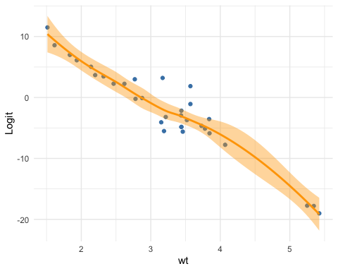

```r
myPlots[[3]]
```

The smooth regression line can take a long time to run for models with large datasets (1000+ points). In this case we can disable the smoothing line with the `smooth` argument:

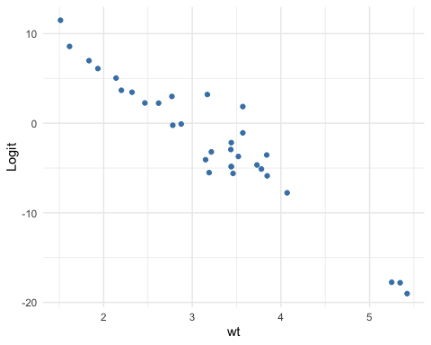

```r
myPlots <- suppressMessages(plotPredictors(fit1, smooth=F))
myPlots[[3]]
```

Alternatively, we can return an interactive plot using the following:

```r
plotPredictors(fit1, interactive = T)
```

```
#> The predictor 'cyl' is discrete.
#> The predictor 'hp' is discrete.
```

[interactive chart not shown]

Currently, there is no option to add a loess smoothing line to the interactive plot, so the “smooth” argument is ignored.

# Model Selection

The model selection phase typically involves reviewing and comparing a number of models. The functions in this section are designed to aid model selection by facilitating model comparison in terms of coefficients and overall model fit.

## listGLM

The `listGLM` function takes one or more fitted `glm` objects as input, and returns them in a list belonging to the new class `listGLM`. The `glm` objects must belong to the “binomial” family.

```r
fit2 <- glm(am ~ cyl + hp, data=mtcars, family = binomial(link = "logit"))
fit3 <- glm(am ~ cyl + wt, data=mtcars, family = binomial(link = "logit"))

listGLM1 <- listGLM(fit1, fit2, fit3)
```

## coef: S3 method for `listGLM`

The `coef` method returns the estimated coefficients and 95% confidence intervals in a `listGLM`. The object returned includes both the model formulae, and a summary of the coefficients for each model. The default usage returns a group of `gt` tables, however, you can also return the data as a list of `data.frame` objects by setting the argument `raw` to T.

```r
gt <- coef(listGLM1)
# For markdown rendering purposes, we use the grp_pull function. In the console, you can print by  calling the object directly.
grp_pull(gt,1)
```

| Model | Variable | Estimate | Lower | Upper | SE |
| --- | --- | --- | --- | --- | --- |
| M1 | (Intercept) | 19.7029000 | 8.55536000 | 44.2516000 | 8.1163700 |
| M2 | (Intercept) | 5.8322000 | 2.24462000 | 10.5732000 | 2.0659500 |
| M3 | (Intercept) | 15.7494000 | 6.80686000 | 32.0219000 | 6.0259400 |
| M1 | cyl | 0.4875980 | -1.53300000 | 3.1204700 | 1.0716200 |
| M2 | cyl | -1.7030600 | -3.13270000 | -0.6840010 | 0.6028620 |
| M3 | cyl | 1.3217300 | 0.07814320 | 3.3932900 | 0.7890060 |
| M1 | hp | 0.0325917 | 0.00332091 | 0.0883896 | 0.0188611 |
| M2 | hp | 0.0277481 | 0.00399841 | 0.0600870 | 0.0136641 |
| M1 | wt | -9.1494700 | -21.36320000 | -3.4815100 | 4.1533200 |
| M3 | wt | -7.8640000 | -16.08440000 | -3.2785400 | 3.0711500 |

```r
grp_pull(gt,2)
```

| Model | Formula |
| --- | --- |
| M1 | am ~ cyl + hp + wt |
| M2 | am ~ cyl + hp |
| M3 | am ~ cyl + wt |

```r
coef(listGLM1, raw=T)
```

```
#> $data
#>    Model    Variable   Estimate        Lower      Upper        SE
#> 1     M1 (Intercept) 19.7029000   8.55536000 44.2516000 8.1163700
#> 5     M2 (Intercept)  5.8322000   2.24462000 10.5732000 2.0659500
#> 8     M3 (Intercept) 15.7494000   6.80686000 32.0219000 6.0259400
#> 2     M1         cyl  0.4875980  -1.53300000  3.1204700 1.0716200
#> 6     M2         cyl -1.7030600  -3.13270000 -0.6840010 0.6028620
#> 9     M3         cyl  1.3217300   0.07814320  3.3932900 0.7890060
#> 3     M1          hp  0.0325917   0.00332091  0.0883896 0.0188611
#> 7     M2          hp  0.0277481   0.00399841  0.0600870 0.0136641
#> 4     M1          wt -9.1494700 -21.36320000 -3.4815100 4.1533200
#> 10    M3          wt -7.8640000 -16.08440000 -3.2785400 3.0711500
#>
#> $formula
#>   Model            Formula
#> 1    M1 am ~ cyl + hp + wt
#> 2    M2      am ~ cyl + hp
#> 3    M3      am ~ cyl + wt
```

Other arguments include whether to exponentiate the coefficients (`exp`), change the number of significant figures (`sigfig`), and include the test statistic and p-values (`expand`). We can also change the confidence interval level (`ci`) and return standard confidence intervals based on asymptotic normality instead of the profile likelihood confidence intervals.

```r
coef(listGLM1, raw=T, exp=T, sigfig = 3, expand=T, ci=0.9, ci_normal=T)
```

```
#> $data
#>    Model    Variable Estimate    Lower    Upper     SE z value p-value
#> 1     M1 (Intercept) 3.60e+08 5.74e+02 2.26e+14 8.1200   2.430 0.01520
#> 5     M2 (Intercept) 3.41e+02 1.14e+01 1.02e+04 2.0700   2.820 0.00476
#> 8     M3 (Intercept) 6.92e+06 3.43e+02 1.39e+11 6.0300   2.610 0.00896
#> 2     M1         cyl 1.63e+00 2.79e-01 9.49e+00 1.0700   0.455 0.64900
#> 6     M2         cyl 1.82e-01 6.76e-02 4.91e-01 0.6030  -2.820 0.00473
#> 9     M3         cyl 3.75e+00 1.02e+00 1.37e+01 0.7890   1.680 0.09390
#> 3     M1          hp 1.03e+00 1.00e+00 1.07e+00 0.0189   1.730 0.08400
#> 7     M2          hp 1.03e+00 1.01e+00 1.05e+00 0.0137   2.030 0.04230
#> 4     M1          wt 1.06e-04 1.15e-07 9.85e-02 4.1500  -2.200 0.02760
#> 10    M3          wt 3.84e-04 2.46e-06 6.01e-02 3.0700  -2.560 0.01040
#>
#> $formula
#>   Model            Formula
#> 1    M1 am ~ cyl + hp + wt
#> 2    M2      am ~ cyl + hp
#> 3    M3      am ~ cyl + wt
```

## plot: S3 method for `listGLM`

We can return a Forest Plot of the estimates and confidence intervals using the `plot` method. The method also accepts arguments to exponentiate coefficients and change the confidence level.

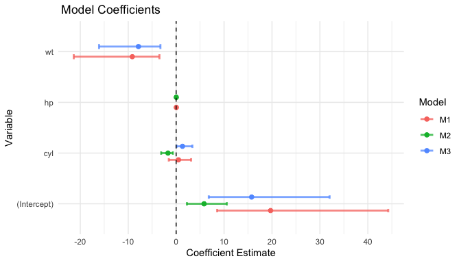

```r
plot(listGLM1, exp=F, ci=0.95, ci_normal=F)
```

## compare: S3 method for `listGLM`

The `compare` method returns the AIC, BIC and McFadden’s Pseudo-R-squared values for each model in the `listGLM` object. By default, a `gt` table is returned.

```r
compare(listGLM1)
```

| formula | AIC | BIC | McFadden | McFaddenAdj |
| --- | --- | --- | --- | --- |
| am ~ cyl + hp + wt | 17.84 | 23.7 | 0.7723 | 0.5873 |
| am ~ cyl + hp | 34.63 | 39.02 | 0.3378 | 0.199 |
| am ~ cyl + wt | 20.73 | 25.13 | 0.6592 | 0.5205 |

Arguments include `raw` (return a `data.frame` object instead), `sigfig` (the number of significant figures to round to) and `expand` (return additional pseudo-R-squared measures).

```r
compare(listGLM1, raw=T, sigfig=3, expand=T)
```

```
#>              formula  AIC  BIC McFadden McFaddenAdj CoxSnell Nagelkerke
#> 1 am ~ cyl + hp + wt 17.8 23.7    0.772       0.587    0.648      0.874
#> 2      am ~ cyl + hp 34.6   39    0.338       0.199    0.366      0.495
#> 3      am ~ cyl + wt 20.7 25.1    0.659        0.52     0.59      0.796
#>   AldrichNelson VeallZimmermann McKelveyZavoina Efron  Tjur
#> 1         0.511           0.889           0.937 0.803  0.81
#> 2         0.313           0.545           0.488 0.397 0.402
#> 3         0.471            0.82           0.915 0.694 0.705
```

## lrtest: S3 method for `listGLM`

Finally, the `lrtest` method performs a Likelihood Ratio test between all pairs of nested models in the `listGLM` object.

- The method uses the `is_nested_models` function from the `insight` package to determine whether the models are nested.
- The S3 method calls an RCPP function (`rcpp_multipleLRTest`), which performs the Likelihood Ratio test.

The default significance level used for the test is 0.05, which can be changed using the `alpha` argument.

```r
lrtest(listGLM1, alpha=0.05)
```

| H0 (alpha=0.05) | p-value | Test Stat | DF | M1 | M2 |
| --- | --- | --- | --- | --- | --- |
| Reject | 1.464e-05 | 18.780 | 1 | am ~ cyl + hp + wt | am ~ cyl + hp |
| Reject | 2.703e-02 | 4.889 | 1 | am ~ cyl + hp + wt | am ~ cyl + wt |

Other arguments include `raw` (return a `data.frame` object instead), `sigfig` (the number of significant figures to round to) and `override` (perform the LR test on all pairs, regardless of nesting).

```r
lrtest(listGLM1, alpha=0.01, raw=T, override=T, sigfig=3)
```

```
#>   H0 (alpha=0.01)  p-value Test Stat DF                 M1            M2
#> 1          Reject 1.46e-05     18.80  1 am ~ cyl + hp + wt am ~ cyl + hp
#> 2   Do Not Reject 2.70e-02      4.89  1 am ~ cyl + hp + wt am ~ cyl + wt
#> 3    Check Models 0.00e+00     13.90  0      am ~ cyl + hp am ~ cyl + wt
```

The `override` flag is to be used at the user’s discretion. For example, the `is_nested_models` function does not consider models using polynomial terms to be nested. For example, the following models would not be compared using default arguments.

$$am \sim cyl + hp + wt$$
$$am \sim cyl + hp + poly(wt,2)$$
The `override` argument allows us to perform the Likelihood Ratio test regardless:

```r
fit4 <- glm(am ~ cyl + hp + poly(wt,2), data=mtcars, family = binomial(link = "logit"))
listGLM2 <- listGLM(fit1, fit4)
lrtest(listGLM2, override=T)
```

| H0 (alpha=0.05) | p-value | Test Stat | DF | M1 | M2 |
| --- | --- | --- | --- | --- | --- |
| Do Not Reject | 0.2135 | 1.548 | 1 | am ~ cyl + hp + wt | am ~ cyl + hp + poly(wt, 2) |